# Project: No-Show Appointments Dataset Analysis

- Introduction
- Data Wrangling
- Exploratory Data Analysis
- Conclusions

## Introduction

> This report investigates the No-Show appointment dataset, The dataset collects information from 100k medical appointments in Brazil. The aim of the report is to question whether or not patients show up for their appointment. A number of characteristics about the patient are included in each row.

### Dataset Description

> . ScheduledDay: Tells us on what day the patient set up their appiontment.

> . AppiontmentDay: Tells us on what day the patient is expected to show up for their appiontment.

> . Gender: Indicates the sex of the patient.

> . Neighborhood: Indicates the location of the hospital.

> . Scholarship: Indicates whether or not the patient is enrolled in the Brasilian welfare program.

> . No-Show: Indicates 'Yes' for a no-show, and 'No' for a patient who showed up.

### Question(s) for Analysis

> 1. What factors influences a patient to show up or not for their scheduled appointment?
> 2. Is sending an SMS as a reminder helpful to reducing the rate of No-Show?
> 3. Which gender received SMS reminder the more?

```python
# Use this cell to set up import statements for all of the packages that you
#   plan to use
import pandas as pd
import numpy as np
import matplotlib.pyplot as plt
%matplotlib inline
import seaborn as sns
```

## Data Wrangling

### General Properties

```python
# Read the dataset
df = pd.read_csv('https://d17h27t6h515a5.cloudfront.net/topher/2017/October/59dd2e9a_noshowappointments-kagglev2-may-2016/noshowappointments-kagglev2-may-2016.csv')
df.head()
```

|  | PatientId | AppointmentID | Gender | ScheduledDay | AppointmentDay | Age | Neighbourhood | Scholarship | Hipertension | Diabetes | Alcoholism | Handcap | SMS_received | No-show |
| --- | --- | --- | --- | --- | --- | --- | --- | --- | --- | --- | --- | --- | --- | --- |
| 0 | 2.987250e+13 | 5642903 | F | 2016-04-29T18:38:08Z | 2016-04-29T00:00:00Z | 62 | JARDIM DA PENHA | 0 | 1 | 0 | 0 | 0 | 0 | No |
| 1 | 5.589978e+14 | 5642503 | M | 2016-04-29T16:08:27Z | 2016-04-29T00:00:00Z | 56 | JARDIM DA PENHA | 0 | 0 | 0 | 0 | 0 | 0 | No |
| 2 | 4.262962e+12 | 5642549 | F | 2016-04-29T16:19:04Z | 2016-04-29T00:00:00Z | 62 | MATA DA PRAIA | 0 | 0 | 0 | 0 | 0 | 0 | No |
| 3 | 8.679512e+11 | 5642828 | F | 2016-04-29T17:29:31Z | 2016-04-29T00:00:00Z | 8 | PONTAL DE CAMBURI | 0 | 0 | 0 | 0 | 0 | 0 | No |
| 4 | 8.841186e+12 | 5642494 | F | 2016-04-29T16:07:23Z | 2016-04-29T00:00:00Z | 56 | JARDIM DA PENHA | 0 | 1 | 1 | 0 | 0 | 0 | No |

```python
# show the summary for all columns
df.describe()
```

|  | PatientId | AppointmentID | Age | Scholarship | Hipertension | Diabetes | Alcoholism | Handcap | SMS_received |
| --- | --- | --- | --- | --- | --- | --- | --- | --- | --- |
| count | 1.105270e+05 | 1.105270e+05 | 110527.000000 | 110527.000000 | 110527.000000 | 110527.000000 | 110527.000000 | 110527.000000 | 110527.000000 |
| mean | 1.474963e+14 | 5.675305e+06 | 37.088874 | 0.098266 | 0.197246 | 0.071865 | 0.030400 | 0.022248 | 0.321026 |
| std | 2.560949e+14 | 7.129575e+04 | 23.110205 | 0.297675 | 0.397921 | 0.258265 | 0.171686 | 0.161543 | 0.466873 |
| min | 3.921784e+04 | 5.030230e+06 | -1.000000 | 0.000000 | 0.000000 | 0.000000 | 0.000000 | 0.000000 | 0.000000 |
| 25% | 4.172614e+12 | 5.640286e+06 | 18.000000 | 0.000000 | 0.000000 | 0.000000 | 0.000000 | 0.000000 | 0.000000 |
| 50% | 3.173184e+13 | 5.680573e+06 | 37.000000 | 0.000000 | 0.000000 | 0.000000 | 0.000000 | 0.000000 | 0.000000 |
| 75% | 9.439172e+13 | 5.725524e+06 | 55.000000 | 0.000000 | 0.000000 | 0.000000 | 0.000000 | 0.000000 | 1.000000 |
| max | 9.999816e+14 | 5.790484e+06 | 115.000000 | 1.000000 | 1.000000 | 1.000000 | 1.000000 | 4.000000 | 1.000000 |

```python
# get the dataset dimensions
df.shape
```

```
(110527, 14)
```

```python
# check for unique value in columns
df.nunique()
```

```
PatientId          62299
AppointmentID     110527
Gender                 2
ScheduledDay      103549
AppointmentDay        27
Age                  104
Neighbourhood         81
Scholarship            2
Hipertension           2
Diabetes               2
Alcoholism             2
Handcap                5
SMS_received           2
No-show                2
dtype: int64
```

```python
# get the datatypes of columns
df.dtypes
```

```
PatientId         float64
AppointmentID       int64
Gender             object
ScheduledDay       object
AppointmentDay     object
Age                 int64
Neighbourhood      object
Scholarship         int64
Hipertension        int64
Diabetes            int64
Alcoholism          int64
Handcap             int64
SMS_received        int64
No-show            object
dtype: object
```

```python
# checking for missing values
df.info()
```

```
<class 'pandas.core.frame.DataFrame'>
RangeIndex: 110527 entries, 0 to 110526
Data columns (total 14 columns):
PatientId         110527 non-null float64
AppointmentID     110527 non-null int64
Gender            110527 non-null object
ScheduledDay      110527 non-null object
AppointmentDay    110527 non-null object
Age               110527 non-null int64
Neighbourhood     110527 non-null object
Scholarship       110527 non-null int64
Hipertension      110527 non-null int64
Diabetes          110527 non-null int64
Alcoholism        110527 non-null int64
Handcap           110527 non-null int64
SMS_received      110527 non-null int64
No-show           110527 non-null object
dtypes: float64(1), int64(8), object(5)
memory usage: 11.8+ MB
```

```python
# check for duplicates
df.duplicated().sum()
```

```
0
```

```python
# check for columns with missing value
df.isnull().sum().any()
```

```
False
```

```python
# check for rows with missing value
df.isna().any(axis=1).sum()
```

```
0
```

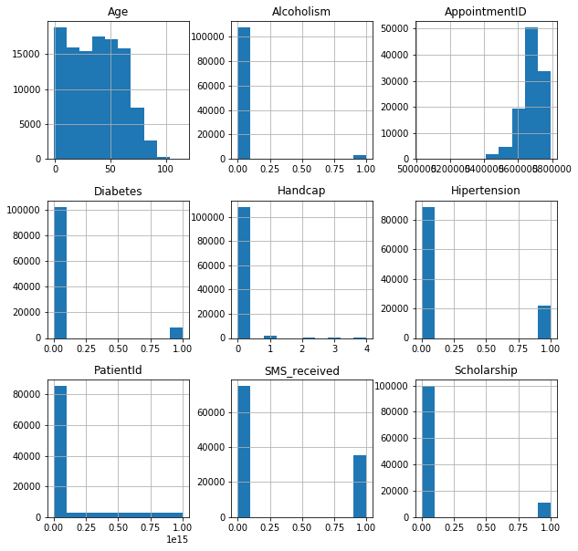

```python
# visualizing the dataframe
df.hist(figsize=(10,10));
```

[output not shown]

```python
# counting numbers of handicap
df['Handcap'].value_counts()
```

```
0    108286
1      2042
2       183
3        13
4         3
Name: Handcap, dtype: int64
```

```
It appears here that there four(4) categories of Handicaps.
Now let's count Age to see if there is any error unusual.
```

```python
# counting Age
df['Age'].value_counts()
```

```
 0      3539
 1      2273
 52     1746
 49     1652
 53     1651
 56     1635
 38     1629
 59     1624
 2      1618
 50     1613
 57     1603
 36     1580
 51     1567
 19     1545
 39     1536
```

[output cut: 47 more lines]

```python
df['Scholarship'].value_counts()
```

```
0    99666
1    10861
Name: Scholarship, dtype: int64
```

```
Let's rename No-show and SMS_received columns to be consistent.
We'll not be interested in AppointmentID in our analysis, so we are dropping it in the cleaning section below.
Let's also change Noshow datatype to boolean .
Let's also change the Age value with -1, which i think must have been an error.
And we'll also rename some mistyped column names such as Handcap and Hipertension.
```

# Data Cleaning

```python
# dropping AppointmentID column
df.drop(['AppointmentID'], axis = 1, inplace = True)
df.head()
```

|  | PatientId | Gender | ScheduledDay | AppointmentDay | Age | Neighbourhood | Scholarship | Hipertension | Diabetes | Alcoholism | Handcap | SMS_received | No-show |
| --- | --- | --- | --- | --- | --- | --- | --- | --- | --- | --- | --- | --- | --- |
| 0 | 2.987250e+13 | F | 2016-04-29T18:38:08Z | 2016-04-29T00:00:00Z | 62 | JARDIM DA PENHA | 0 | 1 | 0 | 0 | 0 | 0 | No |
| 1 | 5.589978e+14 | M | 2016-04-29T16:08:27Z | 2016-04-29T00:00:00Z | 56 | JARDIM DA PENHA | 0 | 0 | 0 | 0 | 0 | 0 | No |
| 2 | 4.262962e+12 | F | 2016-04-29T16:19:04Z | 2016-04-29T00:00:00Z | 62 | MATA DA PRAIA | 0 | 0 | 0 | 0 | 0 | 0 | No |
| 3 | 8.679512e+11 | F | 2016-04-29T17:29:31Z | 2016-04-29T00:00:00Z | 8 | PONTAL DE CAMBURI | 0 | 0 | 0 | 0 | 0 | 0 | No |
| 4 | 8.841186e+12 | F | 2016-04-29T16:07:23Z | 2016-04-29T00:00:00Z | 56 | JARDIM DA PENHA | 0 | 1 | 1 | 0 | 0 | 0 | No |

```python
# renaming mistyped columns
df.rename(columns={'Hipertension':'Hypertension', 'Handcap':'Handicap', 'SMS_received':'SMSreceived', 'No-show':'NoShow'}, inplace=True)
df.head()
```

|  | PatientId | Gender | ScheduledDay | AppointmentDay | Age | Neighbourhood | Scholarship | Hypertension | Diabetes | Alcoholism | Handicap | SMSreceived | NoShow |
| --- | --- | --- | --- | --- | --- | --- | --- | --- | --- | --- | --- | --- | --- |
| 0 | 2.987250e+13 | F | 2016-04-29T18:38:08Z | 2016-04-29T00:00:00Z | 62 | JARDIM DA PENHA | 0 | 1 | 0 | 0 | 0 | 0 | No |
| 1 | 5.589978e+14 | M | 2016-04-29T16:08:27Z | 2016-04-29T00:00:00Z | 56 | JARDIM DA PENHA | 0 | 0 | 0 | 0 | 0 | 0 | No |
| 2 | 4.262962e+12 | F | 2016-04-29T16:19:04Z | 2016-04-29T00:00:00Z | 62 | MATA DA PRAIA | 0 | 0 | 0 | 0 | 0 | 0 | No |
| 3 | 8.679512e+11 | F | 2016-04-29T17:29:31Z | 2016-04-29T00:00:00Z | 8 | PONTAL DE CAMBURI | 0 | 0 | 0 | 0 | 0 | 0 | No |
| 4 | 8.841186e+12 | F | 2016-04-29T16:07:23Z | 2016-04-29T00:00:00Z | 56 | JARDIM DA PENHA | 0 | 1 | 1 | 0 | 0 | 0 | No |

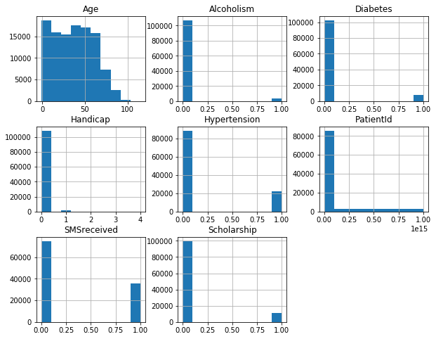

```python
# checking for differences in general hist and after dropping ID
df.hist(figsize=(10, 8));
```

```python
# confirming after dropping
df.info()
```

```
<class 'pandas.core.frame.DataFrame'>
RangeIndex: 110527 entries, 0 to 110526
Data columns (total 13 columns):
PatientId         110527 non-null float64
Gender            110527 non-null object
ScheduledDay      110527 non-null object
AppointmentDay    110527 non-null object
Age               110527 non-null int64
Neighbourhood     110527 non-null object
Scholarship       110527 non-null int64
Hypertension      110527 non-null int64
Diabetes          110527 non-null int64
Alcoholism        110527 non-null int64
Handicap          110527 non-null int64
SMSreceived       110527 non-null int64
NoShow            110527 non-null object
dtypes: float64(1), int64(7), object(5)
memory usage: 11.0+ MB
```

```python
# checking for any duplicate after dropping
df.duplicated().sum()
df.drop_duplicates()
```

|  | PatientId | Gender | ScheduledDay | AppointmentDay | Age | Neighbourhood | Scholarship | Hypertension | Diabetes | Alcoholism | Handicap | SMSreceived | NoShow |
| --- | --- | --- | --- | --- | --- | --- | --- | --- | --- | --- | --- | --- | --- |
| 0 | 2.987250e+13 | F | 2016-04-29T18:38:08Z | 2016-04-29T00:00:00Z | 62 | JARDIM DA PENHA | 0 | 1 | 0 | 0 | 0 | 0 | No |
| 1 | 5.589978e+14 | M | 2016-04-29T16:08:27Z | 2016-04-29T00:00:00Z | 56 | JARDIM DA PENHA | 0 | 0 | 0 | 0 | 0 | 0 | No |
| 2 | 4.262962e+12 | F | 2016-04-29T16:19:04Z | 2016-04-29T00:00:00Z | 62 | MATA DA PRAIA | 0 | 0 | 0 | 0 | 0 | 0 | No |
| 3 | 8.679512e+11 | F | 2016-04-29T17:29:31Z | 2016-04-29T00:00:00Z | 8 | PONTAL DE CAMBURI | 0 | 0 | 0 | 0 | 0 | 0 | No |
| 4 | 8.841186e+12 | F | 2016-04-29T16:07:23Z | 2016-04-29T00:00:00Z | 56 | JARDIM DA PENHA | 0 | 1 | 1 | 0 | 0 | 0 | No |
| 5 | 9.598513e+13 | F | 2016-04-27T08:36:51Z | 2016-04-29T00:00:00Z | 76 | REPÚBLICA | 0 | 1 | 0 | 0 | 0 | 0 | No |
| 6 | 7.336882e+14 | F | 2016-04-27T15:05:12Z | 2016-04-29T00:00:00Z | 23 | GOIABEIRAS | 0 | 0 | 0 | 0 | 0 | 0 | Yes |
| 7 | 3.449833e+12 | F | 2016-04-27T15:39:58Z | 2016-04-29T00:00:00Z | 39 | GOIABEIRAS | 0 | 0 | 0 | 0 | 0 | 0 | Yes |
| 8 | 5.639473e+13 | F | 2016-04-29T08:02:16Z | 2016-04-29T00:00:00Z | 21 | ANDORINHAS | 0 | 0 | 0 | 0 | 0 | 0 | No |
| 9 | 7.812456e+13 | F | 2016-04-27T12:48:25Z | 2016-04-29T00:00:00Z | 19 | CONQUISTA | 0 | 0 | 0 | 0 | 0 | 0 | No |
| 10 | 7.345362e+14 | F | 2016-04-27T14:58:11Z | 2016-04-29T00:00:00Z | 30 | NOVA PALESTINA | 0 | 0 | 0 | 0 | 0 | 0 | No |
| 11 | 7.542951e+12 | M | 2016-04-26T08:44:12Z | 2016-04-29T00:00:00Z | 29 | NOVA PALESTINA | 0 | 0 | 0 | 0 | 0 | 1 | Yes |
| 12 | 5.666548e+14 | F | 2016-04-28T11:33:51Z | 2016-04-29T00:00:00Z | 22 | NOVA PALESTINA | 1 | 0 | 0 | 0 | 0 | 0 | No |
| 13 | 9.113946e+14 | M | 2016-04-28T14:52:07Z | 2016-04-29T00:00:00Z | 28 | NOVA PALESTINA | 0 | 0 | 0 | 0 | 0 | 0 | No |
| 14 | 9.988472e+13 | F | 2016-04-28T10:06:24Z | 2016-04-29T00:00:00Z | 54 | NOVA PALESTINA | 0 | 0 | 0 | 0 | 0 | 0 | No |
| 15 | 9.994839e+10 | F | 2016-04-26T08:47:27Z | 2016-04-29T00:00:00Z | 15 | NOVA PALESTINA | 0 | 0 | 0 | 0 | 0 | 1 | No |
| 16 | 8.457439e+13 | M | 2016-04-28T08:51:47Z | 2016-04-29T00:00:00Z | 50 | NOVA PALESTINA | 0 | 0 | 0 | 0 | 0 | 0 | No |
| 17 | 1.479497e+13 | F | 2016-04-28T09:28:57Z | 2016-04-29T00:00:00Z | 40 | CONQUISTA | 1 | 0 | 0 | 0 | 0 | 0 | Yes |
| 18 | 1.713538e+13 | F | 2016-04-26T10:54:18Z | 2016-04-29T00:00:00Z | 30 | NOVA PALESTINA | 1 | 0 | 0 | 0 | 0 | 1 | No |
| 19 | 7.223289e+12 | F | 2016-04-29T10:43:14Z | 2016-04-29T00:00:00Z | 46 | DA PENHA | 0 | 0 | 0 | 0 | 0 | 0 | No |
| 20 | 6.222575e+14 | F | 2016-04-27T07:51:14Z | 2016-04-29T00:00:00Z | 30 | NOVA PALESTINA | 0 | 0 | 0 | 0 | 0 | 0 | Yes |
| 21 | 1.215484e+13 | F | 2016-04-27T10:50:45Z | 2016-04-29T00:00:00Z | 4 | CONQUISTA | 0 | 0 | 0 | 0 | 0 | 0 | Yes |
| 22 | 8.632298e+14 | M | 2016-04-25T13:29:16Z | 2016-04-29T00:00:00Z | 13 | CONQUISTA | 0 | 0 | 0 | 0 | 0 | 1 | Yes |
| 23 | 2.137540e+14 | F | 2016-04-28T10:27:05Z | 2016-04-29T00:00:00Z | 46 | CONQUISTA | 0 | 0 | 0 | 0 | 0 | 0 | No |
| 24 | 8.734858e+12 | F | 2016-04-29T14:19:19Z | 2016-04-29T00:00:00Z | 65 | TABUAZEIRO | 0 | 0 | 0 | 0 | 0 | 0 | No |
| 25 | 5.819370e+12 | M | 2016-04-26T15:04:17Z | 2016-04-29T00:00:00Z | 46 | CONQUISTA | 0 | 1 | 0 | 0 | 0 | 1 | No |
| 26 | 2.578785e+10 | F | 2016-04-29T14:19:42Z | 2016-04-29T00:00:00Z | 45 | BENTO FERREIRA | 0 | 1 | 0 | 0 | 0 | 0 | No |
| 27 | 1.215484e+13 | F | 2016-04-27T10:51:45Z | 2016-04-29T00:00:00Z | 4 | CONQUISTA | 0 | 0 | 0 | 0 | 0 | 0 | No |
| 28 | 5.926172e+12 | M | 2016-04-29T15:48:02Z | 2016-04-29T00:00:00Z | 51 | SÃO PEDRO | 0 | 0 | 0 | 0 | 0 | 0 | No |
| 29 | 1.225776e+12 | F | 2016-04-29T15:16:29Z | 2016-04-29T00:00:00Z | 32 | SANTA MARTHA | 0 | 0 | 0 | 0 | 0 | 0 | No |
| ... | ... | ... | ... | ... | ... | ... | ... | ... | ... | ... | ... | ... | ... |
| 110497 | 7.935892e+14 | M | 2016-06-01T09:46:33Z | 2016-06-01T00:00:00Z | 76 | MARIA ORTIZ | 0 | 0 | 0 | 0 | 0 | 0 | No |
| 110498 | 9.433654e+13 | F | 2016-06-08T10:21:14Z | 2016-06-08T00:00:00Z | 59 | MARIA ORTIZ | 0 | 0 | 0 | 0 | 0 | 0 | No |
| 110499 | 8.219692e+14 | F | 2016-06-01T09:42:56Z | 2016-06-01T00:00:00Z | 66 | MARIA ORTIZ | 0 | 1 | 1 | 0 | 0 | 0 | No |
| 110500 | 4.434384e+14 | F | 2016-06-08T09:35:13Z | 2016-06-08T00:00:00Z | 59 | MARIA ORTIZ | 0 | 0 | 0 | 0 | 0 | 0 | No |
| 110501 | 4.544252e+11 | M | 2016-06-01T10:19:12Z | 2016-06-01T00:00:00Z | 44 | MARIA ORTIZ | 0 | 0 | 0 | 0 | 0 | 0 | No |
| 110502 | 7.316229e+14 | F | 2016-06-08T10:50:42Z | 2016-06-08T00:00:00Z | 22 | GOIABEIRAS | 0 | 0 | 0 | 0 | 0 | 0 | No |
| 110503 | 2.362182e+13 | F | 2016-06-01T13:00:36Z | 2016-06-01T00:00:00Z | 64 | SOLON BORGES | 0 | 0 | 0 | 0 | 0 | 0 | No |
| 110504 | 9.947983e+12 | F | 2016-06-08T11:06:21Z | 2016-06-08T00:00:00Z | 4 | MARIA ORTIZ | 0 | 0 | 0 | 0 | 0 | 0 | No |
| 110505 | 5.667344e+13 | F | 2016-06-01T10:45:50Z | 2016-06-01T00:00:00Z | 55 | MARIA ORTIZ | 0 | 0 | 0 | 0 | 0 | 0 | No |
| 110506 | 8.973883e+11 | M | 2016-06-01T11:09:20Z | 2016-06-01T00:00:00Z | 5 | MARIA ORTIZ | 0 | 0 | 0 | 0 | 0 | 0 | No |
| 110507 | 4.769462e+14 | F | 2016-06-08T09:04:18Z | 2016-06-08T00:00:00Z | 0 | MARIA ORTIZ | 0 | 0 | 0 | 0 | 0 | 0 | No |
| 110508 | 9.433654e+13 | F | 2016-06-01T09:41:00Z | 2016-06-01T00:00:00Z | 59 | MARIA ORTIZ | 0 | 0 | 0 | 0 | 0 | 0 | No |
| 110509 | 4.952968e+14 | M | 2016-06-08T08:50:51Z | 2016-06-08T00:00:00Z | 33 | MARIA ORTIZ | 0 | 0 | 0 | 0 | 0 | 0 | No |
| 110510 | 2.362182e+13 | F | 2016-06-01T09:35:48Z | 2016-06-01T00:00:00Z | 64 | SOLON BORGES | 0 | 0 | 0 | 0 | 0 | 0 | No |
| 110511 | 8.235996e+11 | F | 2016-06-08T08:50:20Z | 2016-06-08T00:00:00Z | 14 | MARIA ORTIZ | 0 | 0 | 0 | 0 | 0 | 0 | No |
| 110512 | 9.876246e+13 | F | 2016-06-08T08:20:01Z | 2016-06-08T00:00:00Z | 41 | MARIA ORTIZ | 0 | 0 | 0 | 0 | 0 | 0 | No |
| 110513 | 8.674778e+13 | M | 2016-06-08T07:52:55Z | 2016-06-08T00:00:00Z | 2 | ANTÔNIO HONÓRIO | 0 | 0 | 0 | 0 | 0 | 0 | No |
| 110514 | 2.695685e+12 | F | 2016-06-08T08:35:31Z | 2016-06-08T00:00:00Z | 58 | MARIA ORTIZ | 0 | 0 | 0 | 0 | 0 | 0 | No |
| 110515 | 6.456342e+14 | M | 2016-06-06T15:58:05Z | 2016-06-08T00:00:00Z | 33 | MARIA ORTIZ | 0 | 1 | 0 | 0 | 0 | 0 | Yes |
| 110516 | 6.923772e+13 | F | 2016-06-07T07:45:16Z | 2016-06-08T00:00:00Z | 37 | MARIA ORTIZ | 0 | 0 | 0 | 0 | 0 | 0 | Yes |
| 110517 | 5.574942e+12 | F | 2016-06-07T07:38:34Z | 2016-06-07T00:00:00Z | 19 | MARIA ORTIZ | 0 | 0 | 0 | 0 | 0 | 0 | No |
| 110518 | 7.263315e+13 | F | 2016-04-27T15:15:06Z | 2016-06-07T00:00:00Z | 50 | MARIA ORTIZ | 0 | 0 | 0 | 0 | 0 | 1 | No |
| 110519 | 6.542388e+13 | F | 2016-04-27T15:23:14Z | 2016-06-07T00:00:00Z | 22 | MARIA ORTIZ | 0 | 0 | 0 | 0 | 0 | 1 | No |
| 110520 | 9.969977e+14 | F | 2016-05-03T07:51:47Z | 2016-06-07T00:00:00Z | 42 | MARIA ORTIZ | 0 | 0 | 0 | 0 | 0 | 1 | No |
| 110521 | 3.635534e+13 | F | 2016-05-03T08:23:40Z | 2016-06-07T00:00:00Z | 53 | MARIA ORTIZ | 0 | 0 | 0 | 0 | 0 | 1 | No |
| 110522 | 2.572134e+12 | F | 2016-05-03T09:15:35Z | 2016-06-07T00:00:00Z | 56 | MARIA ORTIZ | 0 | 0 | 0 | 0 | 0 | 1 | No |
| 110523 | 3.596266e+12 | F | 2016-05-03T07:27:33Z | 2016-06-07T00:00:00Z | 51 | MARIA ORTIZ | 0 | 0 | 0 | 0 | 0 | 1 | No |
| 110524 | 1.557663e+13 | F | 2016-04-27T16:03:52Z | 2016-06-07T00:00:00Z | 21 | MARIA ORTIZ | 0 | 0 | 0 | 0 | 0 | 1 | No |
| 110525 | 9.213493e+13 | F | 2016-04-27T15:09:23Z | 2016-06-07T00:00:00Z | 38 | MARIA ORTIZ | 0 | 0 | 0 | 0 | 0 | 1 | No |
| 110526 | 3.775115e+14 | F | 2016-04-27T13:30:56Z | 2016-06-07T00:00:00Z | 54 | MARIA ORTIZ | 0 | 0 | 0 | 0 | 0 | 1 | No |

109909 rows × 13 columns

```python
# replacing Age value
df['Age'].replace(-1,0, inplace=True)
```

```python
# confirming Age value after replacing
df['Age'].value_counts()
```

```
0      3540
1      2273
52     1746
49     1652
53     1651
56     1635
38     1629
59     1624
2      1618
50     1613
57     1603
36     1580
51     1567
19     1545
39     1536
```

[output cut: 47 more lines]

```python
# replacing NoShow value
df['NoShow'].replace({'Yes': 1, 'No': 0 }, inplace=True)
```

```python
# confirming
df
```

|  | PatientId | Gender | ScheduledDay | AppointmentDay | Age | Neighbourhood | Scholarship | Hypertension | Diabetes | Alcoholism | Handicap | SMSreceived | NoShow |
| --- | --- | --- | --- | --- | --- | --- | --- | --- | --- | --- | --- | --- | --- |
| 0 | 2.987250e+13 | F | 2016-04-29T18:38:08Z | 2016-04-29T00:00:00Z | 62 | JARDIM DA PENHA | 0 | 1 | 0 | 0 | 0 | 0 | 0 |
| 1 | 5.589978e+14 | M | 2016-04-29T16:08:27Z | 2016-04-29T00:00:00Z | 56 | JARDIM DA PENHA | 0 | 0 | 0 | 0 | 0 | 0 | 0 |
| 2 | 4.262962e+12 | F | 2016-04-29T16:19:04Z | 2016-04-29T00:00:00Z | 62 | MATA DA PRAIA | 0 | 0 | 0 | 0 | 0 | 0 | 0 |
| 3 | 8.679512e+11 | F | 2016-04-29T17:29:31Z | 2016-04-29T00:00:00Z | 8 | PONTAL DE CAMBURI | 0 | 0 | 0 | 0 | 0 | 0 | 0 |
| 4 | 8.841186e+12 | F | 2016-04-29T16:07:23Z | 2016-04-29T00:00:00Z | 56 | JARDIM DA PENHA | 0 | 1 | 1 | 0 | 0 | 0 | 0 |
| 5 | 9.598513e+13 | F | 2016-04-27T08:36:51Z | 2016-04-29T00:00:00Z | 76 | REPÚBLICA | 0 | 1 | 0 | 0 | 0 | 0 | 0 |
| 6 | 7.336882e+14 | F | 2016-04-27T15:05:12Z | 2016-04-29T00:00:00Z | 23 | GOIABEIRAS | 0 | 0 | 0 | 0 | 0 | 0 | 1 |
| 7 | 3.449833e+12 | F | 2016-04-27T15:39:58Z | 2016-04-29T00:00:00Z | 39 | GOIABEIRAS | 0 | 0 | 0 | 0 | 0 | 0 | 1 |
| 8 | 5.639473e+13 | F | 2016-04-29T08:02:16Z | 2016-04-29T00:00:00Z | 21 | ANDORINHAS | 0 | 0 | 0 | 0 | 0 | 0 | 0 |
| 9 | 7.812456e+13 | F | 2016-04-27T12:48:25Z | 2016-04-29T00:00:00Z | 19 | CONQUISTA | 0 | 0 | 0 | 0 | 0 | 0 | 0 |
| 10 | 7.345362e+14 | F | 2016-04-27T14:58:11Z | 2016-04-29T00:00:00Z | 30 | NOVA PALESTINA | 0 | 0 | 0 | 0 | 0 | 0 | 0 |
| 11 | 7.542951e+12 | M | 2016-04-26T08:44:12Z | 2016-04-29T00:00:00Z | 29 | NOVA PALESTINA | 0 | 0 | 0 | 0 | 0 | 1 | 1 |
| 12 | 5.666548e+14 | F | 2016-04-28T11:33:51Z | 2016-04-29T00:00:00Z | 22 | NOVA PALESTINA | 1 | 0 | 0 | 0 | 0 | 0 | 0 |
| 13 | 9.113946e+14 | M | 2016-04-28T14:52:07Z | 2016-04-29T00:00:00Z | 28 | NOVA PALESTINA | 0 | 0 | 0 | 0 | 0 | 0 | 0 |
| 14 | 9.988472e+13 | F | 2016-04-28T10:06:24Z | 2016-04-29T00:00:00Z | 54 | NOVA PALESTINA | 0 | 0 | 0 | 0 | 0 | 0 | 0 |
| 15 | 9.994839e+10 | F | 2016-04-26T08:47:27Z | 2016-04-29T00:00:00Z | 15 | NOVA PALESTINA | 0 | 0 | 0 | 0 | 0 | 1 | 0 |
| 16 | 8.457439e+13 | M | 2016-04-28T08:51:47Z | 2016-04-29T00:00:00Z | 50 | NOVA PALESTINA | 0 | 0 | 0 | 0 | 0 | 0 | 0 |
| 17 | 1.479497e+13 | F | 2016-04-28T09:28:57Z | 2016-04-29T00:00:00Z | 40 | CONQUISTA | 1 | 0 | 0 | 0 | 0 | 0 | 1 |
| 18 | 1.713538e+13 | F | 2016-04-26T10:54:18Z | 2016-04-29T00:00:00Z | 30 | NOVA PALESTINA | 1 | 0 | 0 | 0 | 0 | 1 | 0 |
| 19 | 7.223289e+12 | F | 2016-04-29T10:43:14Z | 2016-04-29T00:00:00Z | 46 | DA PENHA | 0 | 0 | 0 | 0 | 0 | 0 | 0 |
| 20 | 6.222575e+14 | F | 2016-04-27T07:51:14Z | 2016-04-29T00:00:00Z | 30 | NOVA PALESTINA | 0 | 0 | 0 | 0 | 0 | 0 | 1 |
| 21 | 1.215484e+13 | F | 2016-04-27T10:50:45Z | 2016-04-29T00:00:00Z | 4 | CONQUISTA | 0 | 0 | 0 | 0 | 0 | 0 | 1 |
| 22 | 8.632298e+14 | M | 2016-04-25T13:29:16Z | 2016-04-29T00:00:00Z | 13 | CONQUISTA | 0 | 0 | 0 | 0 | 0 | 1 | 1 |
| 23 | 2.137540e+14 | F | 2016-04-28T10:27:05Z | 2016-04-29T00:00:00Z | 46 | CONQUISTA | 0 | 0 | 0 | 0 | 0 | 0 | 0 |
| 24 | 8.734858e+12 | F | 2016-04-29T14:19:19Z | 2016-04-29T00:00:00Z | 65 | TABUAZEIRO | 0 | 0 | 0 | 0 | 0 | 0 | 0 |
| 25 | 5.819370e+12 | M | 2016-04-26T15:04:17Z | 2016-04-29T00:00:00Z | 46 | CONQUISTA | 0 | 1 | 0 | 0 | 0 | 1 | 0 |
| 26 | 2.578785e+10 | F | 2016-04-29T14:19:42Z | 2016-04-29T00:00:00Z | 45 | BENTO FERREIRA | 0 | 1 | 0 | 0 | 0 | 0 | 0 |
| 27 | 1.215484e+13 | F | 2016-04-27T10:51:45Z | 2016-04-29T00:00:00Z | 4 | CONQUISTA | 0 | 0 | 0 | 0 | 0 | 0 | 0 |
| 28 | 5.926172e+12 | M | 2016-04-29T15:48:02Z | 2016-04-29T00:00:00Z | 51 | SÃO PEDRO | 0 | 0 | 0 | 0 | 0 | 0 | 0 |
| 29 | 1.225776e+12 | F | 2016-04-29T15:16:29Z | 2016-04-29T00:00:00Z | 32 | SANTA MARTHA | 0 | 0 | 0 | 0 | 0 | 0 | 0 |
| ... | ... | ... | ... | ... | ... | ... | ... | ... | ... | ... | ... | ... | ... |
| 110497 | 7.935892e+14 | M | 2016-06-01T09:46:33Z | 2016-06-01T00:00:00Z | 76 | MARIA ORTIZ | 0 | 0 | 0 | 0 | 0 | 0 | 0 |
| 110498 | 9.433654e+13 | F | 2016-06-08T10:21:14Z | 2016-06-08T00:00:00Z | 59 | MARIA ORTIZ | 0 | 0 | 0 | 0 | 0 | 0 | 0 |
| 110499 | 8.219692e+14 | F | 2016-06-01T09:42:56Z | 2016-06-01T00:00:00Z | 66 | MARIA ORTIZ | 0 | 1 | 1 | 0 | 0 | 0 | 0 |
| 110500 | 4.434384e+14 | F | 2016-06-08T09:35:13Z | 2016-06-08T00:00:00Z | 59 | MARIA ORTIZ | 0 | 0 | 0 | 0 | 0 | 0 | 0 |
| 110501 | 4.544252e+11 | M | 2016-06-01T10:19:12Z | 2016-06-01T00:00:00Z | 44 | MARIA ORTIZ | 0 | 0 | 0 | 0 | 0 | 0 | 0 |
| 110502 | 7.316229e+14 | F | 2016-06-08T10:50:42Z | 2016-06-08T00:00:00Z | 22 | GOIABEIRAS | 0 | 0 | 0 | 0 | 0 | 0 | 0 |
| 110503 | 2.362182e+13 | F | 2016-06-01T13:00:36Z | 2016-06-01T00:00:00Z | 64 | SOLON BORGES | 0 | 0 | 0 | 0 | 0 | 0 | 0 |
| 110504 | 9.947983e+12 | F | 2016-06-08T11:06:21Z | 2016-06-08T00:00:00Z | 4 | MARIA ORTIZ | 0 | 0 | 0 | 0 | 0 | 0 | 0 |
| 110505 | 5.667344e+13 | F | 2016-06-01T10:45:50Z | 2016-06-01T00:00:00Z | 55 | MARIA ORTIZ | 0 | 0 | 0 | 0 | 0 | 0 | 0 |
| 110506 | 8.973883e+11 | M | 2016-06-01T11:09:20Z | 2016-06-01T00:00:00Z | 5 | MARIA ORTIZ | 0 | 0 | 0 | 0 | 0 | 0 | 0 |
| 110507 | 4.769462e+14 | F | 2016-06-08T09:04:18Z | 2016-06-08T00:00:00Z | 0 | MARIA ORTIZ | 0 | 0 | 0 | 0 | 0 | 0 | 0 |
| 110508 | 9.433654e+13 | F | 2016-06-01T09:41:00Z | 2016-06-01T00:00:00Z | 59 | MARIA ORTIZ | 0 | 0 | 0 | 0 | 0 | 0 | 0 |
| 110509 | 4.952968e+14 | M | 2016-06-08T08:50:51Z | 2016-06-08T00:00:00Z | 33 | MARIA ORTIZ | 0 | 0 | 0 | 0 | 0 | 0 | 0 |
| 110510 | 2.362182e+13 | F | 2016-06-01T09:35:48Z | 2016-06-01T00:00:00Z | 64 | SOLON BORGES | 0 | 0 | 0 | 0 | 0 | 0 | 0 |
| 110511 | 8.235996e+11 | F | 2016-06-08T08:50:20Z | 2016-06-08T00:00:00Z | 14 | MARIA ORTIZ | 0 | 0 | 0 | 0 | 0 | 0 | 0 |
| 110512 | 9.876246e+13 | F | 2016-06-08T08:20:01Z | 2016-06-08T00:00:00Z | 41 | MARIA ORTIZ | 0 | 0 | 0 | 0 | 0 | 0 | 0 |
| 110513 | 8.674778e+13 | M | 2016-06-08T07:52:55Z | 2016-06-08T00:00:00Z | 2 | ANTÔNIO HONÓRIO | 0 | 0 | 0 | 0 | 0 | 0 | 0 |
| 110514 | 2.695685e+12 | F | 2016-06-08T08:35:31Z | 2016-06-08T00:00:00Z | 58 | MARIA ORTIZ | 0 | 0 | 0 | 0 | 0 | 0 | 0 |
| 110515 | 6.456342e+14 | M | 2016-06-06T15:58:05Z | 2016-06-08T00:00:00Z | 33 | MARIA ORTIZ | 0 | 1 | 0 | 0 | 0 | 0 | 1 |
| 110516 | 6.923772e+13 | F | 2016-06-07T07:45:16Z | 2016-06-08T00:00:00Z | 37 | MARIA ORTIZ | 0 | 0 | 0 | 0 | 0 | 0 | 1 |
| 110517 | 5.574942e+12 | F | 2016-06-07T07:38:34Z | 2016-06-07T00:00:00Z | 19 | MARIA ORTIZ | 0 | 0 | 0 | 0 | 0 | 0 | 0 |
| 110518 | 7.263315e+13 | F | 2016-04-27T15:15:06Z | 2016-06-07T00:00:00Z | 50 | MARIA ORTIZ | 0 | 0 | 0 | 0 | 0 | 1 | 0 |
| 110519 | 6.542388e+13 | F | 2016-04-27T15:23:14Z | 2016-06-07T00:00:00Z | 22 | MARIA ORTIZ | 0 | 0 | 0 | 0 | 0 | 1 | 0 |
| 110520 | 9.969977e+14 | F | 2016-05-03T07:51:47Z | 2016-06-07T00:00:00Z | 42 | MARIA ORTIZ | 0 | 0 | 0 | 0 | 0 | 1 | 0 |
| 110521 | 3.635534e+13 | F | 2016-05-03T08:23:40Z | 2016-06-07T00:00:00Z | 53 | MARIA ORTIZ | 0 | 0 | 0 | 0 | 0 | 1 | 0 |
| 110522 | 2.572134e+12 | F | 2016-05-03T09:15:35Z | 2016-06-07T00:00:00Z | 56 | MARIA ORTIZ | 0 | 0 | 0 | 0 | 0 | 1 | 0 |
| 110523 | 3.596266e+12 | F | 2016-05-03T07:27:33Z | 2016-06-07T00:00:00Z | 51 | MARIA ORTIZ | 0 | 0 | 0 | 0 | 0 | 1 | 0 |
| 110524 | 1.557663e+13 | F | 2016-04-27T16:03:52Z | 2016-06-07T00:00:00Z | 21 | MARIA ORTIZ | 0 | 0 | 0 | 0 | 0 | 1 | 0 |
| 110525 | 9.213493e+13 | F | 2016-04-27T15:09:23Z | 2016-06-07T00:00:00Z | 38 | MARIA ORTIZ | 0 | 0 | 0 | 0 | 0 | 1 | 0 |
| 110526 | 3.775115e+14 | F | 2016-04-27T13:30:56Z | 2016-06-07T00:00:00Z | 54 | MARIA ORTIZ | 0 | 0 | 0 | 0 | 0 | 1 | 0 |

110527 rows × 13 columns

```python
# changing data type
df['NoShow'] = df['NoShow'].astype('bool')
```

```
Have to convert NoShow to a boolean datatype so we can visualize it.
```

```python
# confirming
df.dtypes
```

```
PatientId         float64
Gender             object
ScheduledDay       object
AppointmentDay     object
Age                 int64
Neighbourhood      object
Scholarship         int64
Hypertension        int64
Diabetes            int64
Alcoholism          int64
Handicap            int64
SMSreceived         int64
NoShow               bool
dtype: object
```

```
Can't visualize Scholarship, Hypertension, Alcoholism, SMSreceived and Diabetes columns because they show a NAN values, so let's change their datatypes.
Let's change Neighbourhood, Handicap, and Gender to categorical data.
Let's also make AppointmentDay and ScheduledDay into datetime.
```

```python
# changing columns datatypes to boolean
for c in ['Scholarship', 'Alcoholism', 'Hypertension', 'SMSreceived', 'Diabetes']:
    df[c] = df[c].astype('bool')
```

```python
# changing to category
for c in ['Handicap', 'Gender', 'Neighbourhood']:
    df[c] = df[c].astype('category')
```

```python
# changing to datetime
for c in ['AppointmentDay', 'ScheduledDay']:
    df[c] = pd.to_datetime(df[c])
```

```python
# confirming change
df.dtypes
```

```
PatientId                float64
Gender                  category
ScheduledDay      datetime64[ns]
AppointmentDay    datetime64[ns]
Age                        int64
Neighbourhood           category
Scholarship                 bool
Hypertension                bool
Diabetes                    bool
Alcoholism                  bool
Handicap                category
SMSreceived                 bool
NoShow                      bool
dtype: object
```

## Exploratory Data Analysis

Now let's answer some of the questions listed above

### Research Question 1 ( What factors influences a patient to show up or not for their scheduled appointments?)

```python
# checking for correlation between variables
df.corr('spearman').style.background_gradient(cmap="Blues")
```

|  | PatientId | Age | Scholarship | Hypertension | Diabetes | Alcoholism | SMSreceived | NoShow |
| --- | --- | --- | --- | --- | --- | --- | --- | --- |
| PatientId | 1 | -0.00166901 | -0.000544955 | 0.00236915 | 0.00635885 | 0.00788945 | -0.0082618 | -0.000711497 |
| Age | -0.00166901 | 1 | -0.0900988 | 0.503204 | 0.29332 | 0.102266 | 0.0153892 | -0.0612281 |
| Scholarship | -0.000544955 | -0.0900988 | 1 | -0.0197288 | -0.0248935 | 0.0350225 | 0.00119401 | 0.029135 |
| Hypertension | 0.00236915 | 0.503204 | -0.0197288 | 1 | 0.433086 | 0.0879708 | -0.00626686 | -0.0357012 |
| Diabetes | 0.00635885 | 0.29332 | -0.0248935 | 0.433086 | 1 | 0.0184735 | -0.01455 | -0.0151799 |
| Alcoholism | 0.00788945 | 0.102266 | 0.0350225 | 0.0879708 | 0.0184735 | 1 | -0.0261474 | -0.000196044 |
| SMSreceived | -0.0082618 | 0.0153892 | 0.00119401 | -0.00626686 | -0.01455 | -0.0261474 | 1 | 0.126431 |
| NoShow | -0.000711497 | -0.0612281 | 0.029135 | -0.0357012 | -0.0151799 | -0.000196044 | 0.126431 | 1 |

It appears here that there is the highiest correlation between Hypertension and Diabetes, Hypertension and Age, and Diabetes and Age.

```python
grouping = ['Age', 'Gender', 'Hypertension', 'Neighbourhood', 'Scholarship', 'Diabetes', 'Alcoholism', 'SMSreceived']
```

```python
# defining NoShow that are true
noshow = df[df['NoShow'] == True ]
```

```python
# checking the lenght
len(noshow)
```

```
22319
```

```python
# defining NoShow that are false
show = df[df['NoShow'] == False ]
```

```python
# checkimg the lenght
len(show)
```

```
88208
```

```python
# confirming
show
```

|  | PatientId | Gender | ScheduledDay | AppointmentDay | Age | Neighbourhood | Scholarship | Hypertension | Diabetes | Alcoholism | Handicap | SMSreceived | NoShow |
| --- | --- | --- | --- | --- | --- | --- | --- | --- | --- | --- | --- | --- | --- |
| 0 | 2.987250e+13 | F | 2016-04-29 18:38:08 | 2016-04-29 | 62 | JARDIM DA PENHA | False | True | False | False | 0 | False | False |
| 1 | 5.589978e+14 | M | 2016-04-29 16:08:27 | 2016-04-29 | 56 | JARDIM DA PENHA | False | False | False | False | 0 | False | False |
| 2 | 4.262962e+12 | F | 2016-04-29 16:19:04 | 2016-04-29 | 62 | MATA DA PRAIA | False | False | False | False | 0 | False | False |
| 3 | 8.679512e+11 | F | 2016-04-29 17:29:31 | 2016-04-29 | 8 | PONTAL DE CAMBURI | False | False | False | False | 0 | False | False |
| 4 | 8.841186e+12 | F | 2016-04-29 16:07:23 | 2016-04-29 | 56 | JARDIM DA PENHA | False | True | True | False | 0 | False | False |
| 5 | 9.598513e+13 | F | 2016-04-27 08:36:51 | 2016-04-29 | 76 | REPÚBLICA | False | True | False | False | 0 | False | False |
| 8 | 5.639473e+13 | F | 2016-04-29 08:02:16 | 2016-04-29 | 21 | ANDORINHAS | False | False | False | False | 0 | False | False |
| 9 | 7.812456e+13 | F | 2016-04-27 12:48:25 | 2016-04-29 | 19 | CONQUISTA | False | False | False | False | 0 | False | False |
| 10 | 7.345362e+14 | F | 2016-04-27 14:58:11 | 2016-04-29 | 30 | NOVA PALESTINA | False | False | False | False | 0 | False | False |
| 12 | 5.666548e+14 | F | 2016-04-28 11:33:51 | 2016-04-29 | 22 | NOVA PALESTINA | True | False | False | False | 0 | False | False |
| 13 | 9.113946e+14 | M | 2016-04-28 14:52:07 | 2016-04-29 | 28 | NOVA PALESTINA | False | False | False | False | 0 | False | False |
| 14 | 9.988472e+13 | F | 2016-04-28 10:06:24 | 2016-04-29 | 54 | NOVA PALESTINA | False | False | False | False | 0 | False | False |
| 15 | 9.994839e+10 | F | 2016-04-26 08:47:27 | 2016-04-29 | 15 | NOVA PALESTINA | False | False | False | False | 0 | True | False |
| 16 | 8.457439e+13 | M | 2016-04-28 08:51:47 | 2016-04-29 | 50 | NOVA PALESTINA | False | False | False | False | 0 | False | False |
| 18 | 1.713538e+13 | F | 2016-04-26 10:54:18 | 2016-04-29 | 30 | NOVA PALESTINA | True | False | False | False | 0 | True | False |
| 19 | 7.223289e+12 | F | 2016-04-29 10:43:14 | 2016-04-29 | 46 | DA PENHA | False | False | False | False | 0 | False | False |
| 23 | 2.137540e+14 | F | 2016-04-28 10:27:05 | 2016-04-29 | 46 | CONQUISTA | False | False | False | False | 0 | False | False |
| 24 | 8.734858e+12 | F | 2016-04-29 14:19:19 | 2016-04-29 | 65 | TABUAZEIRO | False | False | False | False | 0 | False | False |
| 25 | 5.819370e+12 | M | 2016-04-26 15:04:17 | 2016-04-29 | 46 | CONQUISTA | False | True | False | False | 0 | True | False |
| 26 | 2.578785e+10 | F | 2016-04-29 14:19:42 | 2016-04-29 | 45 | BENTO FERREIRA | False | True | False | False | 0 | False | False |
| 27 | 1.215484e+13 | F | 2016-04-27 10:51:45 | 2016-04-29 | 4 | CONQUISTA | False | False | False | False | 0 | False | False |
| 28 | 5.926172e+12 | M | 2016-04-29 15:48:02 | 2016-04-29 | 51 | SÃO PEDRO | False | False | False | False | 0 | False | False |
| 29 | 1.225776e+12 | F | 2016-04-29 15:16:29 | 2016-04-29 | 32 | SANTA MARTHA | False | False | False | False | 0 | False | False |
| 30 | 3.428156e+11 | F | 2016-04-27 10:24:52 | 2016-04-29 | 46 | NOVA PALESTINA | False | False | False | False | 0 | False | False |
| 32 | 5.288356e+13 | M | 2016-04-29 07:30:27 | 2016-04-29 | 61 | SÃO CRISTÓVÃO | False | True | False | False | 0 | False | False |
| 33 | 7.653517e+12 | F | 2016-04-25 15:01:04 | 2016-04-29 | 38 | SÃO CRISTÓVÃO | True | False | False | False | 0 | True | False |
| 34 | 1.999976e+13 | F | 2016-04-29 07:34:30 | 2016-04-29 | 79 | SÃO CRISTÓVÃO | False | True | False | False | 0 | False | False |
| 35 | 7.816264e+13 | M | 2016-04-29 07:34:42 | 2016-04-29 | 18 | SÃO CRISTÓVÃO | False | False | False | False | 0 | False | False |
| 36 | 7.298459e+13 | F | 2016-04-29 07:35:19 | 2016-04-29 | 63 | SÃO CRISTÓVÃO | False | True | True | False | 0 | False | False |
| 37 | 1.578132e+12 | F | 2016-04-29 07:35:56 | 2016-04-29 | 64 | TABUAZEIRO | True | True | True | False | 0 | False | False |
| ... | ... | ... | ... | ... | ... | ... | ... | ... | ... | ... | ... | ... | ... |
| 110494 | 2.895817e+14 | F | 2016-06-06 17:44:14 | 2016-06-08 | 38 | MARIA ORTIZ | False | False | False | False | 0 | False | False |
| 110495 | 7.499489e+12 | M | 2016-06-01 13:49:47 | 2016-06-01 | 40 | MARIA ORTIZ | False | False | False | False | 0 | False | False |
| 110497 | 7.935892e+14 | M | 2016-06-01 09:46:33 | 2016-06-01 | 76 | MARIA ORTIZ | False | False | False | False | 0 | False | False |
| 110498 | 9.433654e+13 | F | 2016-06-08 10:21:14 | 2016-06-08 | 59 | MARIA ORTIZ | False | False | False | False | 0 | False | False |
| 110499 | 8.219692e+14 | F | 2016-06-01 09:42:56 | 2016-06-01 | 66 | MARIA ORTIZ | False | True | True | False | 0 | False | False |
| 110500 | 4.434384e+14 | F | 2016-06-08 09:35:13 | 2016-06-08 | 59 | MARIA ORTIZ | False | False | False | False | 0 | False | False |
| 110501 | 4.544252e+11 | M | 2016-06-01 10:19:12 | 2016-06-01 | 44 | MARIA ORTIZ | False | False | False | False | 0 | False | False |
| 110502 | 7.316229e+14 | F | 2016-06-08 10:50:42 | 2016-06-08 | 22 | GOIABEIRAS | False | False | False | False | 0 | False | False |
| 110503 | 2.362182e+13 | F | 2016-06-01 13:00:36 | 2016-06-01 | 64 | SOLON BORGES | False | False | False | False | 0 | False | False |
| 110504 | 9.947983e+12 | F | 2016-06-08 11:06:21 | 2016-06-08 | 4 | MARIA ORTIZ | False | False | False | False | 0 | False | False |
| 110505 | 5.667344e+13 | F | 2016-06-01 10:45:50 | 2016-06-01 | 55 | MARIA ORTIZ | False | False | False | False | 0 | False | False |
| 110506 | 8.973883e+11 | M | 2016-06-01 11:09:20 | 2016-06-01 | 5 | MARIA ORTIZ | False | False | False | False | 0 | False | False |
| 110507 | 4.769462e+14 | F | 2016-06-08 09:04:18 | 2016-06-08 | 0 | MARIA ORTIZ | False | False | False | False | 0 | False | False |
| 110508 | 9.433654e+13 | F | 2016-06-01 09:41:00 | 2016-06-01 | 59 | MARIA ORTIZ | False | False | False | False | 0 | False | False |
| 110509 | 4.952968e+14 | M | 2016-06-08 08:50:51 | 2016-06-08 | 33 | MARIA ORTIZ | False | False | False | False | 0 | False | False |
| 110510 | 2.362182e+13 | F | 2016-06-01 09:35:48 | 2016-06-01 | 64 | SOLON BORGES | False | False | False | False | 0 | False | False |
| 110511 | 8.235996e+11 | F | 2016-06-08 08:50:20 | 2016-06-08 | 14 | MARIA ORTIZ | False | False | False | False | 0 | False | False |
| 110512 | 9.876246e+13 | F | 2016-06-08 08:20:01 | 2016-06-08 | 41 | MARIA ORTIZ | False | False | False | False | 0 | False | False |
| 110513 | 8.674778e+13 | M | 2016-06-08 07:52:55 | 2016-06-08 | 2 | ANTÔNIO HONÓRIO | False | False | False | False | 0 | False | False |
| 110514 | 2.695685e+12 | F | 2016-06-08 08:35:31 | 2016-06-08 | 58 | MARIA ORTIZ | False | False | False | False | 0 | False | False |
| 110517 | 5.574942e+12 | F | 2016-06-07 07:38:34 | 2016-06-07 | 19 | MARIA ORTIZ | False | False | False | False | 0 | False | False |
| 110518 | 7.263315e+13 | F | 2016-04-27 15:15:06 | 2016-06-07 | 50 | MARIA ORTIZ | False | False | False | False | 0 | True | False |
| 110519 | 6.542388e+13 | F | 2016-04-27 15:23:14 | 2016-06-07 | 22 | MARIA ORTIZ | False | False | False | False | 0 | True | False |
| 110520 | 9.969977e+14 | F | 2016-05-03 07:51:47 | 2016-06-07 | 42 | MARIA ORTIZ | False | False | False | False | 0 | True | False |
| 110521 | 3.635534e+13 | F | 2016-05-03 08:23:40 | 2016-06-07 | 53 | MARIA ORTIZ | False | False | False | False | 0 | True | False |
| 110522 | 2.572134e+12 | F | 2016-05-03 09:15:35 | 2016-06-07 | 56 | MARIA ORTIZ | False | False | False | False | 0 | True | False |
| 110523 | 3.596266e+12 | F | 2016-05-03 07:27:33 | 2016-06-07 | 51 | MARIA ORTIZ | False | False | False | False | 0 | True | False |
| 110524 | 1.557663e+13 | F | 2016-04-27 16:03:52 | 2016-06-07 | 21 | MARIA ORTIZ | False | False | False | False | 0 | True | False |
| 110525 | 9.213493e+13 | F | 2016-04-27 15:09:23 | 2016-06-07 | 38 | MARIA ORTIZ | False | False | False | False | 0 | True | False |
| 110526 | 3.775115e+14 | F | 2016-04-27 13:30:56 | 2016-06-07 | 54 | MARIA ORTIZ | False | False | False | False | 0 | True | False |

88208 rows × 13 columns

It appears that 88208 patients showedup and 22319 patients never show up for the Appointments

```python
# defining countplot
def count_plot(dfdata, xdata, gxlabel, gylabel, hue_order, gtitle):
    g = sns.countplot(data = dfdata, x = xdata, hue = hue_order)
    plt.title(gtitle)
    plt.xlabel(gxlabel)
    plt.ylabel(gylabel)
    return g
```

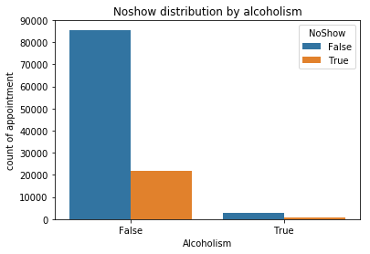

```python
# distribution of alcoholism
g = count_plot(df, 'Alcoholism', 'Alcoholism', 'count of appointment', 'NoShow', 'Noshow distribution by alcoholism')
plt.show()
```

```python
# checking for NoShow mean
df2 = df["NoShow"].mean()
print(df2)
```

```
0.201932559465
```

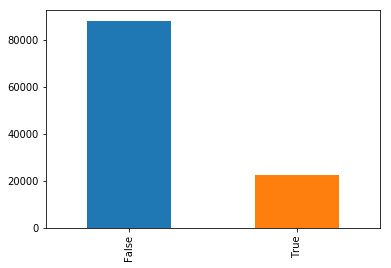

```python
# visualizing NoShow Dataframe
df['NoShow'].value_counts().plot.bar()
```

There about 22319 patients who didn't showup for their Appointments, while about 88000 plus showedup for their appointments.

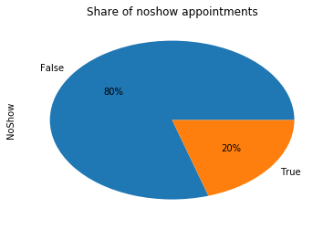

```python
# checking for the share of NoShows in %
df.NoShow.value_counts().plot(kind='pie',autopct='%1.0f%%')
plt.title('Share of noshow appointments')
plt.show()
```

This shows that 80% of patients who booked appointment actually showedup, but 20% of the patients didn't come for the appointment i.e they missed.

## Age

```python
# checking for Age mean
df2 = df["Age"].mean()
print(df2)
```

```
37.0888832593
```

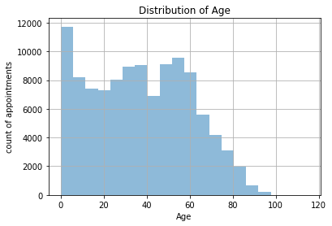

```python
# checking Age distribution
g = df.Age.hist(alpha=0.5, bins=20)
g.set(xlabel = 'Age', ylabel = 'count of appointments', title = 'Distribution of Age')
plt.show()
```

> Children appears to have the highest rate of appointments, espacially between age 0-5(zero to five) years.So this means that children are more in need of medical attention.

> The second group of patients with more appointments are patients of age 40, 50 to 55 years.

## Neighbourhood

```python
# counting neighbourhood
df["Neighbourhood"].value_counts()
```

```
JARDIM CAMBURI                 7717
MARIA ORTIZ                    5805
RESISTÊNCIA                    4431
JARDIM DA PENHA                3877
ITARARÉ                        3514
CENTRO                         3334
TABUAZEIRO                     3132
SANTA MARTHA                   3131
JESUS DE NAZARETH              2853
BONFIM                         2773
SANTO ANTÔNIO                  2746
SANTO ANDRÉ                    2571
CARATOÍRA                      2565
JABOUR                         2509
SÃO PEDRO                      2448
ILHA DO PRÍNCIPE               2266
NOVA PALESTINA                 2264
ANDORINHAS                     2262
DA PENHA                       2217
ROMÃO                          2215
GURIGICA                       2018
SÃO JOSÉ                       1977
BELA VISTA                     1907
MARUÍPE                        1902
FORTE SÃO JOÃO                 1889
ILHA DE SANTA MARIA            1885
SÃO CRISTÓVÃO                  1836
REDENÇÃO                       1553
SÃO BENEDITO                   1439
JOANA D´ARC                    1427
                               ...
SANTOS REIS                     547
ESTRELINHA                      538
SANTA CLARA                     506
SOLON BORGES                    469
PIEDADE                         452
SANTA CECÍLIA                   448
SANTA LÚCIA                     438
SANTA LUÍZA                     428
BARRO VERMELHO                  423
DO MOSCOSO                      413
MÁRIO CYPRESTE                  371
BOA VISTA                       312
COMDUSA                         310
DE LOURDES                      305
ARIOVALDO FAVALESSA             282
ANTÔNIO HONÓRIO                 271
FRADINHOS                       258
ENSEADA DO SUÁ                  235
SANTA HELENA                    178
HORTO                           175
UNIVERSITÁRIO                   152
SEGURANÇA DO LAR                145
NAZARETH                        135
MORADA DE CAMBURI                96
PONTAL DE CAMBURI                69
ILHA DO BOI                      35
ILHA DO FRADE                    10
AEROPORTO                         8
ILHAS OCEÂNICAS DE TRINDADE       2
PARQUE INDUSTRIAL                 1
Name: Neighbourhood, Length: 81, dtype: int64
```

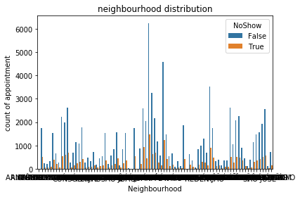

```python
# checking neighbourhood distribution
g = count_plot(df, 'Neighbourhood', 'Neighbourhood', 'count of appointment', 'NoShow', 'neighbourhood distribution')
plt.show()
```

JARDIM CARBURI neighbourhood has the highest number of patients who showedup for their appointments.

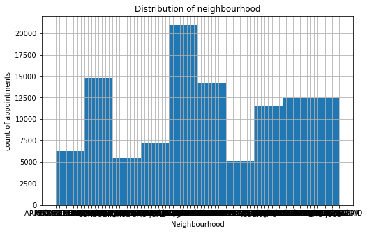

```python
# checking Age distribution
g = df.Neighbourhood.hist(alpha=1.0, figsize=(8,5))
g.set(xlabel = 'Neighbourhood', ylabel = 'count of appointments', title = 'Distribution of neighbourhood')
plt.show()
```

## Gender

```python
# counting NoShow in Gender
noshow_by_gender = df.groupby(['Gender', 'NoShow']).count()
noshow_by_gender
```

| Gender | NoShow | PatientId | ScheduledDay | AppointmentDay | Age | Neighbourhood | Scholarship | Hypertension | Diabetes | Alcoholism | Handicap | SMSreceived |
| --- | --- | --- | --- | --- | --- | --- | --- | --- | --- | --- | --- | --- |
| F | False | 57246 | 57246 | 57246 | 57246 | 57246 | 57246 | 57246 | 57246 | 57246 | 57246 | 57246 |
|  | True | 14594 | 14594 | 14594 | 14594 | 14594 | 14594 | 14594 | 14594 | 14594 | 14594 | 14594 |
| M | False | 30962 | 30962 | 30962 | 30962 | 30962 | 30962 | 30962 | 30962 | 30962 | 30962 | 30962 |
|  | True | 7725 | 7725 | 7725 | 7725 | 7725 | 7725 | 7725 | 7725 | 7725 | 7725 | 7725 |

Appointments of female patients has the highest rate, but males have a lower rate of No showups

```python
# defining the dataframe of Gender
x=df["Gender"].value_counts()
```

```python
x
```

```
F    71840
M    38687
Name: Gender, dtype: int64
```

```
 [Text(-0.499318,0.980143,'Female'), Text(0.499318,-0.980143,'Male')],
 [Text(-0.272356,0.534624,'65%'), Text(0.272355,-0.534624,'35%')])
```

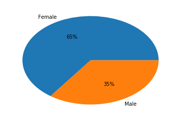

```python
# visualizing Gender in percentage
plt.pie(x, labels=["Female", "Male"],autopct='%1.0f%%')
```

From the chart above, it appears that 65% of patients are Females, while 35% of patients who booked Appointments are Males.

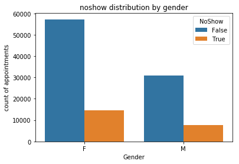

```python
# checking Gender distribution
g = count_plot(df, 'Gender', 'Gender', 'count of appointments', 'NoShow', 'noshow distribution by gender')
plt.show()
```

Females here seems to have a larger count of appointment, which means Female care more for their health.

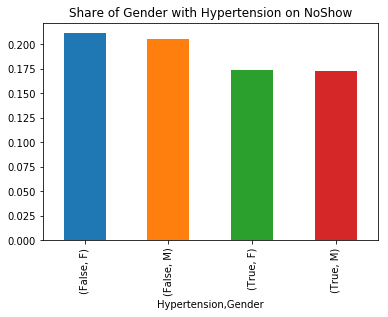

```python
# let's check for distribution of genders with hypertension
df.groupby(['Hypertension', 'Gender']).NoShow.mean().plot(kind='bar')
plt.title('Share of Gender with Hypertension on NoShow')
Hue = 'NoShow'
plt.show()
```

[output not shown]

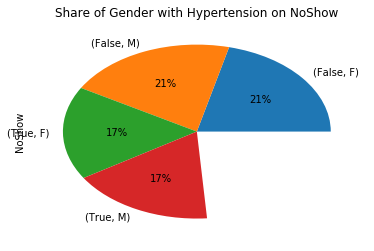

```python
# using pie to visualize in percentage
df.groupby(['Hypertension', 'Gender']).NoShow.mean().plot(kind='pie', autopct='%1.0f%%');
plt.title('Share of Gender with Hypertension on NoShow')
```

## Hypertension

```python
df.Hypertension.value_counts()
```

```
False    88726
True     21801
Name: Hypertension, dtype: int64
```

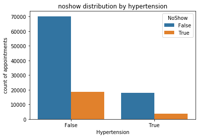

```python
# noshow distribution by hypertension
g = count_plot(df, 'Hypertension', 'Hypertension', 'count of appointments', 'NoShow', 'noshow distribution by hypertension')
plt.show()
```

Here the No showup rate for patients with hypertension is likely to be low.

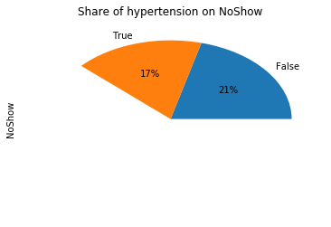

```
False    88726
True     21801
Name: Hypertension, dtype: int64
```

```python
# checking in percentage with value count
df.groupby(['Hypertension']).NoShow.mean().plot(kind='pie', autopct= '%1.0f%%')
plt.title('Share of hypertension on NoShow')
plt.show()
df.Hypertension.value_counts()
```

## Alcoholism

```
False    107167
True       3360
Name: Alcoholism, dtype: int64
```

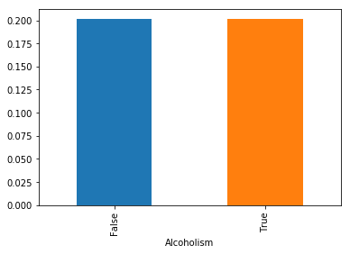

```python
# checing for share of Alcoholism in NoShow
df.groupby('Alcoholism').NoShow.mean().plot(kind= 'bar');
df.Alcoholism.value_counts()
```

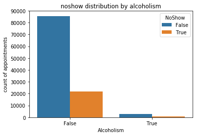

```python
# counting noshow distribution by alcoholism
g = count_plot(df, 'Alcoholism', 'Alcoholism', 'count of appointments', 'NoShow', 'noshow distribution by alcoholism')
plt.show()
```

And because it's an addiction, there are more likely not to book an appointment.

```
Text(0.5,1,'Share of alcoholism on NoShow')
```

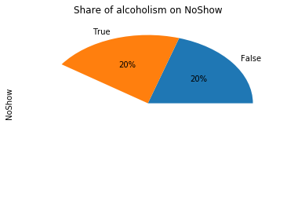

```python
# visualizing handicap
df.groupby(['Alcoholism']).NoShow.mean().plot(kind='pie', autopct='%1.0f%%');
plt.title('Share of alcoholism on NoShow')
```

## Diabetes

```python
# counting Diabetes
df["Diabetes"].value_counts()
```

```
False    102584
True       7943
Name: Diabetes, dtype: int64
```

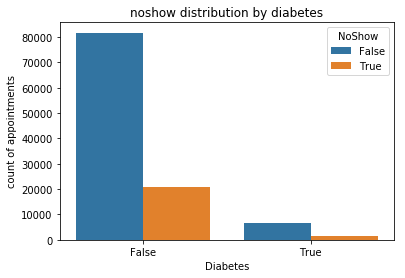

```python
# checking for Diabetes in NoShow
g = count_plot(df, 'Diabetes', 'Diabetes', 'count of appointments', 'NoShow', 'noshow distribution by diabetes')
plt.show()
```

Appointments of patients with Diabetes seems have a lower noshow up rate than those without the disease who missed their appointments.

```
Text(0.5,1,'Share of diabetes on NoShow')
```

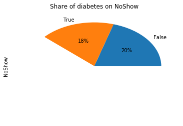

```python
# visualizing diabetes
df.groupby(['Diabetes']).NoShow.mean().plot(kind='pie', autopct='%1.0f%%');
plt.title('Share of diabetes on NoShow')
```

## Handicap

```python
# defining handicap counts
y = df["Handicap"].value_counts()
```

```python
# checking
y
```

```
0    108286
1      2042
2       183
3        13
4         3
Name: Handicap, dtype: int64
```

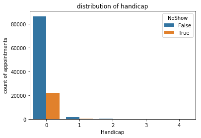

```python
# share of handicap in noshow
g = count_plot(df, 'Handicap', 'Handicap', 'count of appointments', 'NoShow', 'distribution of handicap')
plt.show()
```

```
Text(0.5,1,'Share of handicap on NoShow')
```

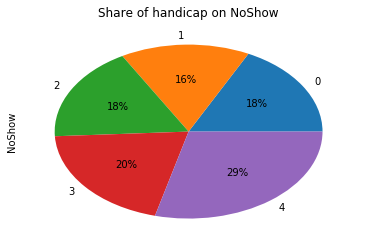

```python
# visualizing handicap
df.groupby(['Handicap']).NoShow.mean().plot(kind='pie', autopct='%1.0f%%');
plt.title('Share of handicap on NoShow')
```

## Scholarship

```python
# checking for Scholarship mean in NoShow
df.groupby('Scholarship').NoShow.mean()
```

```
Scholarship
False    0.198072
True     0.237363
Name: NoShow, dtype: float64
```

```python
# counting scholarship value
df["Scholarship"].value_counts()
```

```
False    99666
True     10861
Name: Scholarship, dtype: int64
```

```
False    99666
True     10861
Name: Scholarship, dtype: int64
```

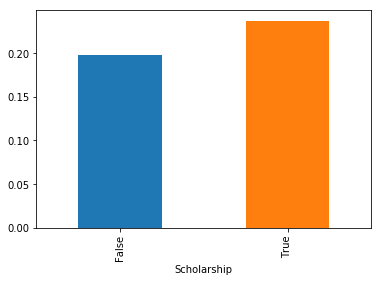

```python
# visualizing Scholarship in NoShow
df.groupby('Scholarship').NoShow.mean().plot(kind= 'bar');
df.Scholarship.value_counts()
```

Appointments of patients with Scholarship is more higher than that of those without scholarships.

```
Text(0.5,1,'Share of scholarship on NoShow')
```

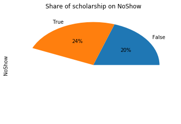

```python
# visualizing scholarship
df.groupby(['Scholarship']).NoShow.mean().plot(kind='pie', autopct='%1.0f%%');
plt.title('Share of scholarship on NoShow')
```

So patients on Scholarship is 24% which is 4% higher than those without Scholarship.

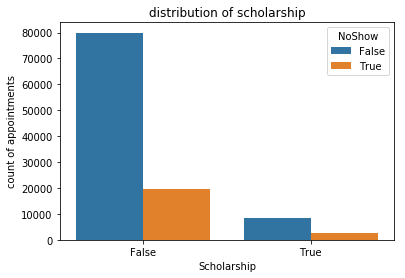

```python
# scholarship distribution
g = count_plot(df, 'Scholarship', 'Scholarship', 'count of appointments', 'NoShow', 'distribution of scholarship')
plt.show()
```

### Research Question 2 (Is sending an SMS as a reminder helpful to reducing the rate of No-Show?)

```
False    75045
True     35482
Name: SMSreceived, dtype: int64
```

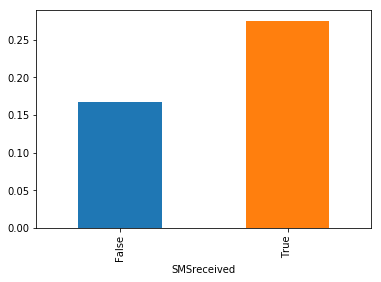

```python
# visualizing SMSreceived to showingup
df.groupby('SMSreceived').NoShow.mean().plot(kind= 'bar');
df.SMSreceived.value_counts()
```

[figure not shown]

```python
# checking Smsreceived distribution
g = count_plot(df, 'SMSreceived', 'SMSreceived', 'count of appointments', 'NoShow', 'share of scholarship on noshow')
plt.show()
```

From the data displayed above, the rate of patients who received SMS is 35482, which is far below 75045 patients who didn't get an SMS.

```
Text(0.5,1,'Share of smsreceived on NoShow')
```

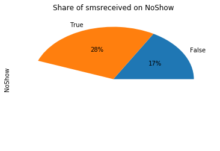

```python
# visualizing smsreceived in %
df.groupby(['SMSreceived']).NoShow.mean().plot(kind='pie', autopct='%1.0f%%');
plt.title('Share of smsreceived on NoShow')
```

## Q3: Which gender received SMS reminder the more?

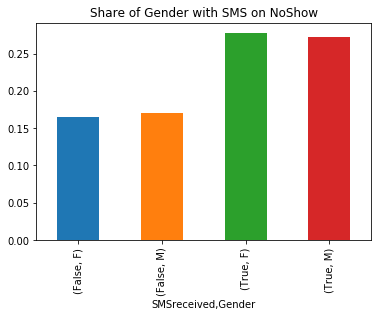

```python
# checking for distribution of gender with sms
df.groupby(['SMSreceived', 'Gender']).NoShow.mean().plot(kind='bar')
plt.title('Share of Gender with SMS on NoShow')
plt.show()
```

Appointments of the female gender who got an sms, and females who didn't get a reminder appears to be of thesame rate when compared to that of the male gender.

```
Text(0.5,1,'Share of Gender with SMS on NoShow')
```

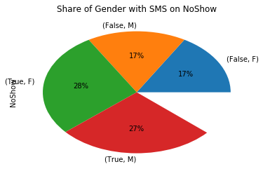

```python
# checking with percentage
df.groupby(['SMSreceived', 'Gender']).NoShow.mean().plot(kind='pie', autopct = '%1.0f%%');
plt.title('Share of Gender with SMS on NoShow')
```

## Q1: What factors influences a patient to show up or not for their scheduled appointments?

While carrying out the Exploratory Data Analysis, I discovered the findings below:

> Appointments of patients with hypertension have a lower no showup rate compare to patients without the disease.

> Appointments of patients with Diabetes seems to have a lower noshow up rate than those without the disease who missed their appointments.

> Despite the large number of females with appointments, the males who are few has a higher showup rate compare to females who missed their appointments.

## Limitations:

Not enough details are given about the patients as to why they didn't come.Such as:

> Their emotions

> Not understanding the scheduling system

> And their financial status

```python
from subprocess import call
call(['python', '-m', 'nbconvert', 'Investigate_a_Dataset.ipynb'])
```

```
0
```